# DSP_HW2_325214492

## Homework 2 - DSP

#### Aylon Feraru i.d: 325214492

#### Shay Bach i.d: 316147016

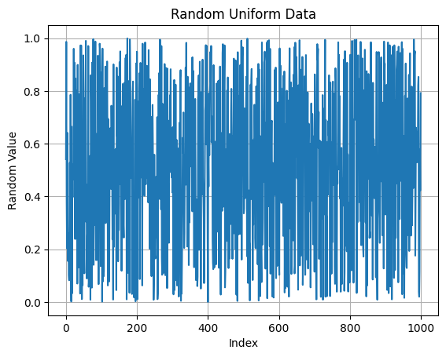

```python
import matplotlib.pyplot as plt
import numpy as np
from scipy.signal import lfilter
import scipy.signal
import dsp_hw1_py as hw1  # Importing the first homework's file converted to Python.

hw1.Rect(1, 2, 60)


def Rand(N: int) -> np.ndarray:
    return np.random.uniform(0, 1, N)


random_data = Rand(1000)
hw1.basic_plot(range(1000), random_data, "Index", "Random Value", "Random Uniform Data")
```

#### Uniform Explanation:

a uniform R.V is between $[0,1]$, we have a vector of $1000$ such samples

```python
def Conj(x: np.ndarray) -> np.ndarray: #Conv in hw document
    y = np.conj(x)
    return y
```

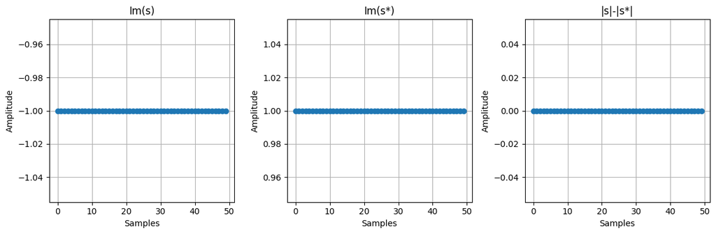

```python
signal = np.ones(50)*(-1j)
signal_conj = Conj(signal)
hw1.plot_three_side_by_side(np.arange(len(signal)),np.imag(signal), np.arange(len(signal)), np.imag(signal_conj), np.arange(len(signal)),np.abs(signal)-np.abs(signal_conj),titles=["Im(s)","Im(s*)","|s|-|s*|"])
```

#### Conj Explanation:

We have a vector of $-j$, we look at its imaginary value, at its conjugate, and we verify that the magnitude did not change.

```python
def Threshold(x: np.ndarray, th: float) -> np.ndarray:
    y = np.zeros_like(x)

    if x.ndim == 1:  # For 1D arrays
        for i in range(len(x)):
            if x[i] >= th:
                y[i] = x[i]
    elif x.ndim == 2:  # For 2D matrices
        for i in range(x.shape[0]):
            for j in range(x.shape[1]):
                if np.abs(x[i, j]) >= th: #will be used on spectrograms, input is complex
                    y[i, j] = x[i, j]
    return y
```

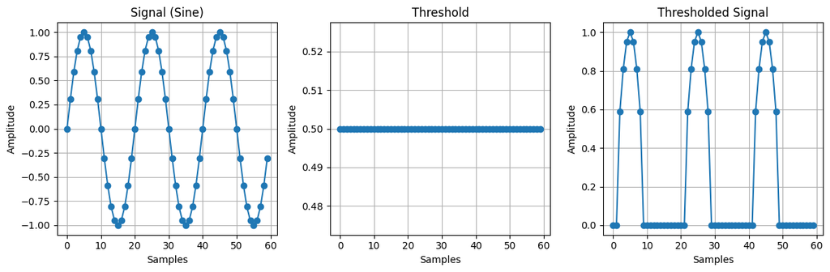

```python
signal = hw1.Sine(3,60,0)
th = 0.5
hw1.plot_three_side_by_side(np.arange(60), signal, np.arange(60), th*np.ones(60), np.arange(60), Threshold(signal,th=th),titles=["Signal (Sine)","Threshold","Thresholded Signal"])
```

#### Threshold Explanation

A sine, when it's bigger than 0.5 (selected threshold) it retains its value, otherwise the value drops to 0

```python
def Complex(f: float, N: int) -> np.ndarray:
    # Generate the complex signal
    real = hw1.Sine(f=f, N=N, ph=np.pi/2)  # Cosine component
    imaginary = hw1.Scalar(1j, hw1.Sine(f=f, N=N, ph=0))  # Sine component scaled by 1j
    return hw1.Add(real, imaginary)
```

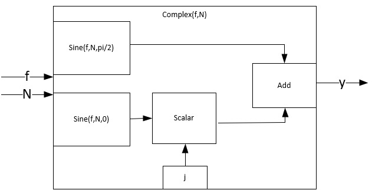

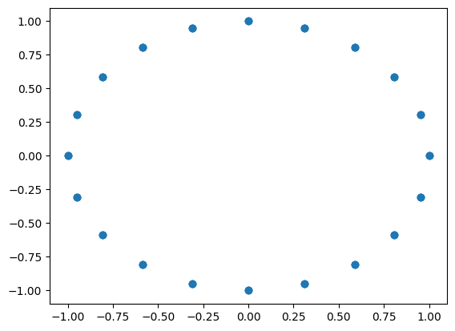

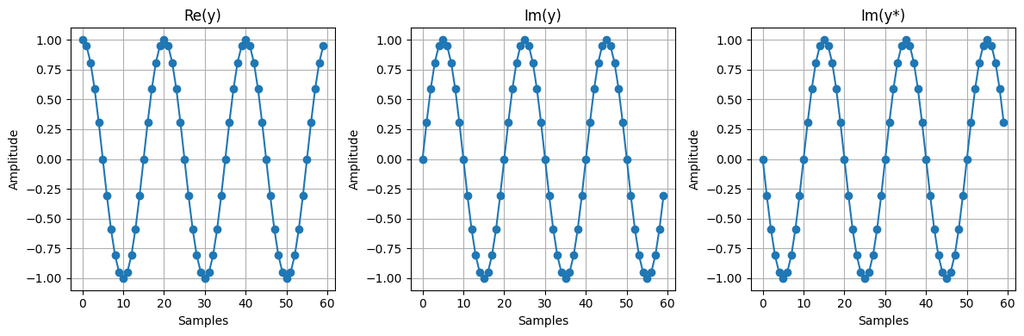

```python
signal_c = Complex(f=3, N=60)
index = np.arange(60)
plt.scatter(signal_c.real,signal_c.imag)
hw1.plot_three_side_by_side(index, np.real(signal_c), index,
                            np.imag(signal_c), index,  Conj(signal_c).imag , titles=["Re(y)","Im(y)","Im(y*)"])
```

### PART 2 - STFT

#### STFT explanation

In order to compute an STFT more efficiently we can look at convolving a Rectangle of size $M$ and support $N$ with the full signal,  
multiply it by a complex twiddle with $M$ in the denominator and decimate with a factor of $\downarrow M$.  
This will give us for an exponent of frequency $k_0$, all the DFT points for all the windows that are related to said $k_0$. Why?

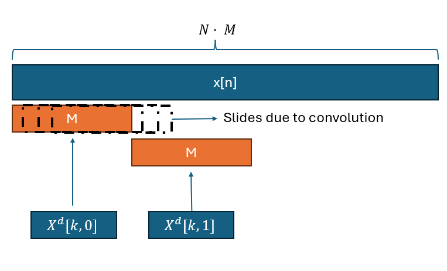

if we look at the first outcome of the valid convolution, we get $X^d[n=0,k_0] = \sum_{i=0}^{M-1} x[n]w[n]e^{-j \frac{2\pi k_0 m}{M}}$, this is the first sample of the DFT of the first window - and the first sample of the STFT's row.  
since we're decimating with a factor of $M$, the next point we retain (after we discard $M-1$ points and the window has shifted $M-1$ positions) is the DFT of $x[n]w[n-M]$, or $X^d[n=1,k_0]$. We can see that as we continue that pattern, with one convolution we essentially get all the coefficients of the different DFTs for this particular frequency - or a single row of the STFT!  
(sidenote: if we were to decimate by something smaller than the window size, we'd get built in overlap!).  
so to get the entire STFT, all we have to do is the following block diagram:

#### STFT Block Diagram

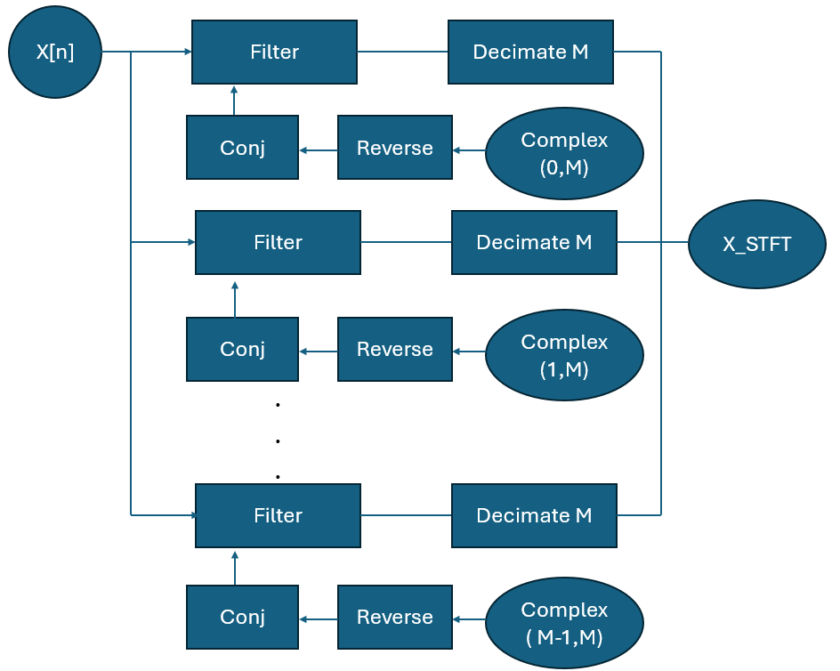

Scipy's STFT (for reference)

```python
signal = [1,2,3,4,5,6,7,8,9,10,-6,-42,2,100,2]
# STFT parameters
fs = 1  # Sampling frequency
nperseg = 5  # Window length
noverlap = 0  # No overlap
window = np.ones(nperseg)  # Rectangular window of ones
boundary = None  # No padding

# Compute the STFT using scipy.signal.stft
frequencies, times, Zxx = scipy.signal.stft(signal, fs=fs, window=window, nperseg=nperseg, noverlap=noverlap, boundary=boundary, padded=False, return_onesided=False)
```

### Reverse and Sampler Helper Functions:

**Reverse**

- given an array of size $N$ that is an exponential, the function will return a reversed signal. How does it work?
  Conjugating a signal is the same as reversing it through time, multiplied by a constant phase.
  We conjugate the signal, and sample the complex exponential at a specific point to get that phase. $$x[n] = e^{\frac{-j 2\pi f}{N} n} \quad n=[0,1,\dots, N-1]$$ $$x_{\text{reversed}}[n] = \underbrace{\text{Conj}(x[n])}_{e^{j \frac{2 \pi f n}{N}}} \cdot \underbrace{\text{Sampler}(x, N-1)}_{e^{-j \frac{2 \pi f (N-1)}{N}}} = e^{-j \frac{2 \pi f}{N} (N-1-n)} = e^{\frac{-j 2\pi f}{N} k}$$ where $k = [N-1,N-2, \dots, 0]$ essentially we got a time reversal.

**Reverse_c** Works the same as reverse using the same mathematics, but assumes an input of a conjugate instead of a regular Complex function, and applies conjugate inside the matrix.  
A really minor change so I did not add a block diagram. **Sampler**: to sample a signal at a specific point, we correlate it with a signal of the same length that contains a unit impulse at the specific point we desire.  
Since convolution is correlation with a flipped signal we choose Rect's coefficients such that it'll be $\delta[N-1-n]$, and after the flip $\delta[n]$

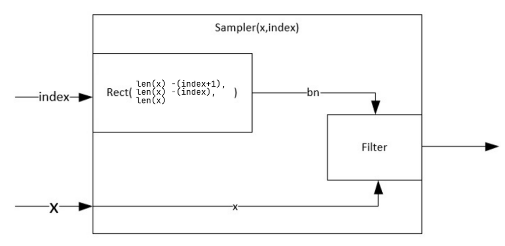

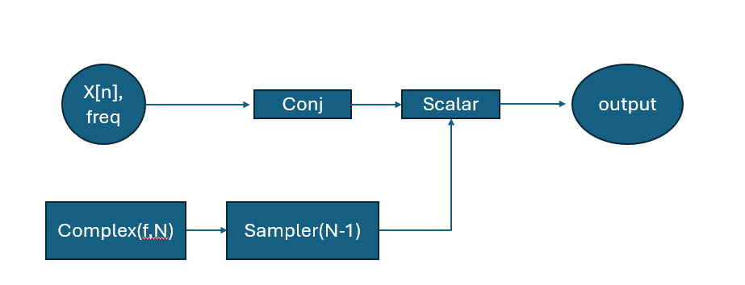

```python
def Sampler(x:np.ndarray, index: int)-> float:
    if index > len(x):
        raise ValueError("Index must be less than the length of the input signal")

    sampling_rect = hw1.Rect(len(x) -(index+1),len(x) -(index),len(x))
    return hw1.Filter([1],bn=sampling_rect,x=x)

def Reverse(exponential_signal: np.ndarray, frequency: int) -> np.ndarray:
    N = len(exponential_signal)
    return hw1.Scalar(Conj(exponential_signal), Sampler(exponential_signal,N-1))
def Reverse_c(exponential_signal: np.ndarray, frequency: int) -> np.ndarray:
    N = len(exponential_signal)
    return hw1.Scalar(Conj(exponential_signal), Sampler(Conj(Complex(frequency,N)),N-1))

print("===Reverse Test===")
print(Complex(3,7))
print(Reverse(Complex(3,7),3))
print("checking equivalence to [::-1]")
print(Complex(3,5) -Reverse(Complex(3,5),3)[::-1] )
```

```
===Reverse Test===
[ 1.      +0.j       -0.900969+0.433884j  0.62349 -0.781831j
 -0.222521+0.974928j -0.222521-0.974928j  0.62349 +0.781831j
 -0.900969-0.433884j]
[-0.900969-0.433884j  0.62349 +0.781831j -0.222521-0.974928j
 -0.222521+0.974928j  0.62349 -0.781831j -0.900969+0.433884j
  1.      -0.j      ]
checking equivalence to [::-1]
[-0.+0.j  0.+0.j  0.-0.j -0.+0.j  0.+0.j]
```

### STFT Implementation:

```python
def STFT(x: np.ndarray, M: int) -> np.ndarray:
    N = len(x) // M
    stft_matrix = np.zeros((M, N), dtype=complex)
    for f in range(M):
        exponential = Conj(Complex(f, M))
        correlated_signal = hw1.Filter([1],x, Reverse(exponential,f))
        stft_matrix[f, :] = hw1.Decimate(M,correlated_signal)
    return stft_matrix
```

#### ISTFT Block Diagram:

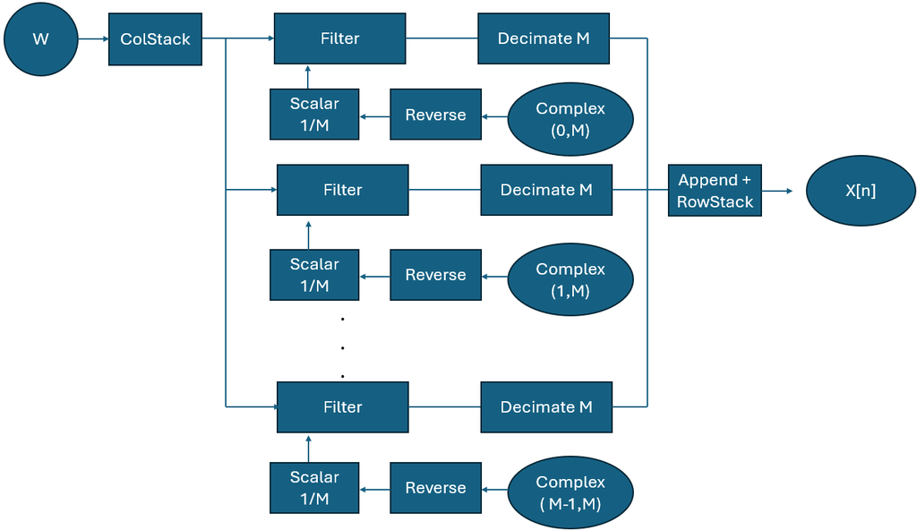

ISTFT Implementation:

```python
def ISTFT(W: np.ndarray) -> np.ndarray:
    M, N = W.shape
    X_colstack = np.matrix.flatten(W, 'F')  # Flatten in column-major order
    x_matrix = np.zeros((N,M), dtype=complex)

    for n in range(M):
        exponential = hw1.Scalar(Complex(n, M),1/M) # Added conjugate here
        correlated_signal = hw1.Filter([1], X_colstack, Reverse(exponential,n))  # Added reversal here
        x_matrix[:,n] = hw1.Decimate(M, correlated_signal)

    return np.matrix.flatten(x_matrix)  # Added real part extraction
```

STFT and ISTFT check:

```python
print(len(signal))

print("MY STFT:")
print(STFT(signal,M=5))  # Transpose for matching dimensions

print("\nSCIPY's STFT:") # Print the magnitude from scipy's STFT
print(Zxx*5)  # Print the magnitude from scipy's STFT

print("the original signal:\n" ,signal)
print("ISTFT(STFT(signal)): \n",(ISTFT(STFT(signal,M=5)))) #abs and int are there for aesthetics only
```

```
15
MY STFT:
[[  15.       +0.j         40.       +0.j         56.       +0.j      ]
 [  -2.5      +3.440955j   -2.5      +3.440955j -100.880413+99.449441j]
 [  -2.5      +0.812299j   -2.5      +0.812299j   57.880413-67.340987j]
 [  -2.5      -0.812299j   -2.5      -0.812299j   57.880413+67.340987j]
 [  -2.5      -3.440955j   -2.5      -3.440955j -100.880413-99.449441j]]

SCIPY's STFT:
[[  15.       +0.j         40.       +0.j         56.       +0.j      ]
 [  -2.5      +3.440955j   -2.5      +3.440955j -100.880413+99.449441j]
 [  -2.5      +0.812299j   -2.5      +0.812299j   57.880413-67.340987j]
 [  -2.5      -0.812299j   -2.5      -0.812299j   57.880413+67.340987j]
 [  -2.5      -3.440955j   -2.5      -3.440955j -100.880413-99.449441j]]
the original signal:
 [1, 2, 3, 4, 5, 6, 7, 8, 9, 10, -6, -42, 2, 100, 2]
ISTFT(STFT(signal)):
 [ 0.2+0.j  0.4+0.j  0.6-0.j  0.8-0.j  1. +0.j  1.2+0.j  1.4+0.j  1.6-0.j
  1.8-0.j  2. +0.j -1.2+0.j -8.4+0.j  0.4+0.j 20. +0.j  0.4+0.j]
```

### ALTERNATE PART 2 - AN INEFFICIENT STFT PROGRAM

I kept it in because I think it's an intuitve and natural way of realizing STFT, despite being horribly inefficient I didn't want to discard the code completely.

#### Complex Explanation:

the complex function works by Add-ing a cosine generated with Sine, and a Sine generated with Sine multiplied by a Scalar $j$. We can see that the real and imaginary components correspond to Euler's formula, and we can see that Conj does work on the imaginary part as it did with any complex signal.

- additionally, we can see that the signal has magnitude one and a changing phase since it orbits in the unit circle as can be seen in the plot above.

```python
def Take_Range(x:np.ndarray, a:int,b:int) -> np.ndarray:
    output = []
    for i in range(a,b):
        output.append(Sampler(x,i))
    return np.array(output).T


def DFT(x:np.ndarray) -> np.ndarray:
    N = len(x)
    summation_rect = hw1.Scalar(hw1.Rect(0,N,N),N)

    X_dft =np.zeros(N,dtype=complex)
    for k in range(N):
        exponent = Conj(Complex(k,N))
        x_comp =hw1.Prod(exponent,x)
        X_dft[k] = hw1.Filter([1],summation_rect,x_comp)
    return X_dft


signal = np.array([3,4,5,6,7,6,5,4,3],dtype=complex)
np.set_printoptions(precision=6, suppress=True)
print("DFT(signal):\n",DFT(signal))
print("Numpy's FFT: \n",np.fft.fft(signal))
```

```
DFT(signal):
 [43.      +0.j       -7.790859-2.835641j  0.216881+0.181985j
 -0.5     -0.866025j  0.073978+0.41955j   0.073978-0.41955j
 -0.5     +0.866025j  0.216881-0.181985j -7.790859+2.835641j]
Numpy's FFT:
 [43.      +0.j       -7.790859-2.835641j  0.216881+0.181985j
 -0.5     -0.866025j  0.073978+0.41955j   0.073978-0.41955j
 -0.5     +0.866025j  0.216881-0.181985j -7.790859+2.835641j]
```

#### Original Helper Functions: Sampler, Take_Range, DFT - Explanation

- we sample a vector x at index i by convolving a window of legnth 1 at that point with our signal
- we repeat this action and append to get a Range
- DFT is just a helper function, since every FFT we take a slice of the signal and perform multiplication with an exponent on it, and then summation $$X^d[k] = \sum_{i=0}^{N-1} x[n]e^{\frac{-2 j \pi k n}{N}}$$

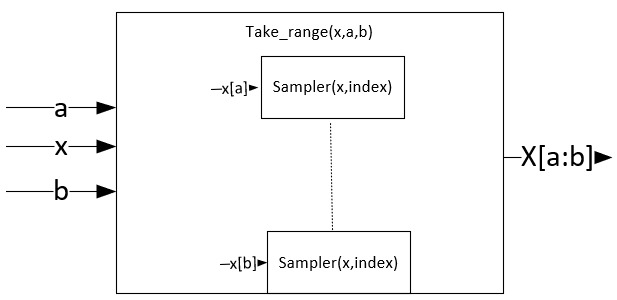

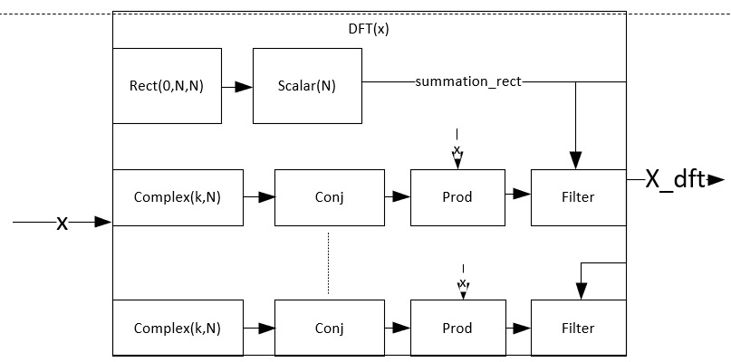

```python
import scipy.signal

def STFT_inefficient(x: np.ndarray, M: np.ndarray) -> np.ndarray:
    N = len(x)//M
    x_i_F = np.array([],dtype=complex)
    matrix =[]
    for i in range(N):
        x_i = Take_Range(x,i*M,(i+1)*M)
        x_i_F =DFT(x_i)
        matrix.append(x_i_F)
    return np.array(matrix, dtype=complex).T


# Define your signal
signal = np.array([0, 2, 2, 2, 3, 4, 5, 5, 5, 5, 5, 5, 5, 4, 4])

# STFT parameters
fs = 1  # Sampling frequency
nperseg = 5  # Window length
noverlap = 0  # No overlap
window = np.ones(nperseg)  # Rectangular window of ones
boundary = None  # No padding

# Compute the STFT using scipy.signal.stft
frequencies, times, Zxx = scipy.signal.stft(signal, fs=fs, window=window, nperseg=nperseg, noverlap=noverlap, boundary=boundary, padded=False, return_onesided=False)

# Set print options globally for numpy
np.set_printoptions(precision=6, suppress=True)  # Limit precision, suppress scientific notation, and format complex numbers

# Print the results with consistent formatting

print("MY STFT:")
print(STFT_inefficient(signal,M=5))  # Transpose for matching dimensions

print("\nSCIPY's STFT:") # Print the magnitude from scipy's STFT
print(Zxx*5)  # Print the magnitude from scipy's STFT
```

```
MY STFT:
[[ 9.      +0.j       24.      +0.j       23.      +0.j      ]
 [-1.690983+0.951057j -1.      +0.j        0.5     -1.538842j]
 [-2.809017+0.587785j -1.      -0.j        0.5     +0.363271j]
 [-2.809017-0.587785j -1.      -0.j        0.5     -0.363271j]
 [-1.690983-0.951057j -1.      -0.j        0.5     +1.538842j]]

SCIPY's STFT:
[[ 9.      +0.j       24.      +0.j       23.      +0.j      ]
 [-1.690983+0.951057j -1.      +0.j        0.5     -1.538842j]
 [-2.809017+0.587785j -1.      +0.j        0.5     +0.363271j]
 [-2.809017-0.587785j -1.      -0.j        0.5     -0.363271j]
 [-1.690983-0.951057j -1.      -0.j        0.5     +1.538842j]]
```

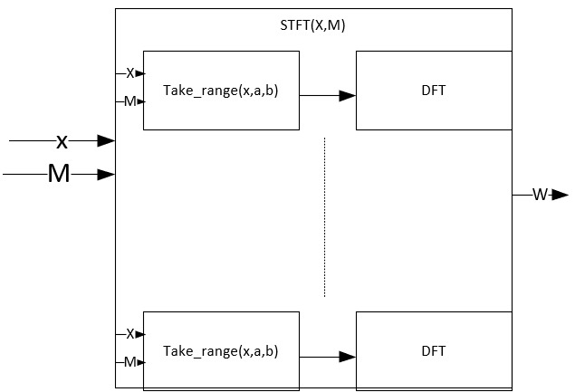

#### ALTERNATE STFT explanation

since we want STFT with no overlap and we made a range helper and a DFT helper, we select a range of values each time, perform a DTFT on them, and append the result in a matrix. We can compare with SCIPY, and we can see that the results match exactly up to transposing, and de-normalizing scipy's FFT by the window length.

#### IDFT Explanation - Helper function

$$x[n] = \frac{1}{N}\sum_{k=0}^{N-1} X^d[k]e^{\frac{2 j \pi k n}{N}}$$ Converts a signal back from its frequency representation to its time representation, code is identical to DFT up to changing the sign of the exponent, and retaining the normalizing factor of 1/N (that we discarded in the DFT).

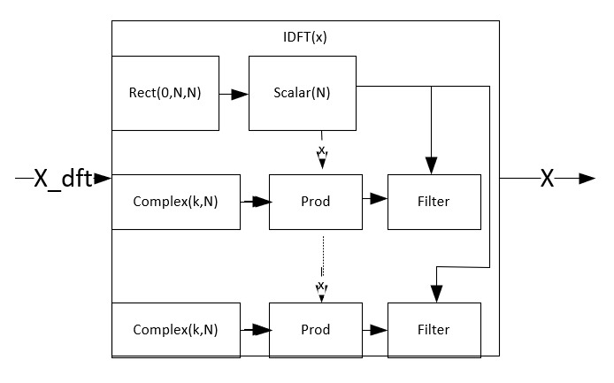

```python
def IDFT_inefficient(x:np.ndarray) -> np.ndarray:
    N = len(x)
    summation_rect = hw1.Rect(0,N,N)

    X_Idft =np.zeros(N,dtype=complex)
    for k in range(N):
        exponent = Complex(k,N)
        x_comp =hw1.Prod(exponent,x)
        X_Idft[k] = hw1.Filter([1],summation_rect,x_comp)
    return X_Idft
```

```python
signal = np.array([3,4,5,6,7,6,5,4,3])
np.set_printoptions(precision=6, suppress=True)
print("signal:\n",signal)
print("DFT(signal):\n",DFT(signal))
print("IDFT(DFT(signal)): \n",np.abs(IDFT_inefficient(DFT(signal)))) #abs is there for aesthetics, removes +0j and -0j
```

```
signal:
 [3 4 5 6 7 6 5 4 3]
DFT(signal):
 [43.      +0.j       -7.790859-2.835641j  0.216881+0.181985j
 -0.5     -0.866025j  0.073978+0.41955j   0.073978-0.41955j
 -0.5     +0.866025j  0.216881-0.181985j -7.790859+2.835641j]
IDFT(DFT(signal)):
 [3. 4. 5. 6. 7. 6. 5. 4. 3.]
```

```python
def ISTFT_inefficient(W: np.ndarray) -> np.ndarray:# every row is an
    M=W.shape[0]
    N=W.shape[1]
    x = np.zeros(M*N,dtype=complex)
    for i in range(N):
        x[i*M:(i+1)*M] = IDFT_inefficient(W[:,i])
    return x
signal = np.array([0, 2, 2, 2, 3, 4, 5, 5, 5, 5, 5, 5, 5, 4, 4])
print(len(signal))
print("the original signal:\n" ,signal)
print("ISTFT(STFT(signal)): \n",ISTFT_inefficient(STFT_inefficient(signal,M=5))) #abs and int are there for aesthetics only
```

```
15
the original signal:
 [0 2 2 2 3 4 5 5 5 5 5 5 5 4 4]
ISTFT(STFT(signal)):
 [-0.-0.j  2.+0.j  2.+0.j  2.-0.j  3.-0.j  4.-0.j  5.+0.j  5.-0.j  5.+0.j
  5.-0.j  5.-0.j  5.+0.j  5.+0.j  4.-0.j  4.-0.j]
```

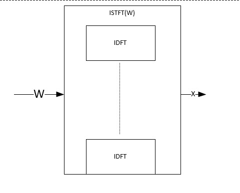

### ALTERNATE ISTFT explanation

we seperate each section which we previously transformed to the frequency domain with a DFT, and return it back to the time domain via the IDFT helper function.  
Afterwards, we append each section of length $M$ to a signal that matches the dimensions of the original time signal $(M \cdot N)$, and get the original signal back.

### PART 3

#### Setting Up Basic Signals:

```python
gaussian_noise_signal = hw1.WGN(4096,0,1)
low_pass_filter = hw1.Rect(0,6,6)
gaussian_noise_lpf = hw1.Filter([1],low_pass_filter, hw1.WGN(4101,0,1))
high_pass_filter = hw1.Add(hw1.Rect(0,1,2), hw1.Scalar(hw1.Rect(1,2,2),-1))
gaussian_noise_hpf =  hw1.Filter([1],high_pass_filter,hw1.WGN(4097,0,1))

known_sines = []
unknown_sines = []
random_frequencies = hw1.Scalar(Rand(5),5)
for i in range(5):
    known_sines.append(hw1.Sine(f=i*500,N=4096,ph=0))
    unknown_sines.append(hw1.Sine(f=random_frequencies[i]*500,N=4096,ph=0))
```

### Creating Three Signals as a Linear Combination:

```python
signal_1 = hw1.Add(hw1.Add(hw1.Scalar(gaussian_noise_hpf ,1),hw1.Scalar(gaussian_noise_lpf,-1)), hw1.Scalar(unknown_sines[3],np.pi)) #signal is a sine of unknown frequency
signal_2 = hw1.Add(hw1.Add(hw1.Scalar(known_sines[2] ,4),hw1.Scalar(known_sines[1],2)), hw1.Scalar(unknown_sines[2],1)) # signal is known_sine[1]
signal_3 = hw1.Add(hw1.Add(hw1.Scalar(known_sines[4] ,4),hw1.Scalar(gaussian_noise_signal,5)), hw1.Scalar(unknown_sines[1],50)) #signal is a sine of unknown frequency
```

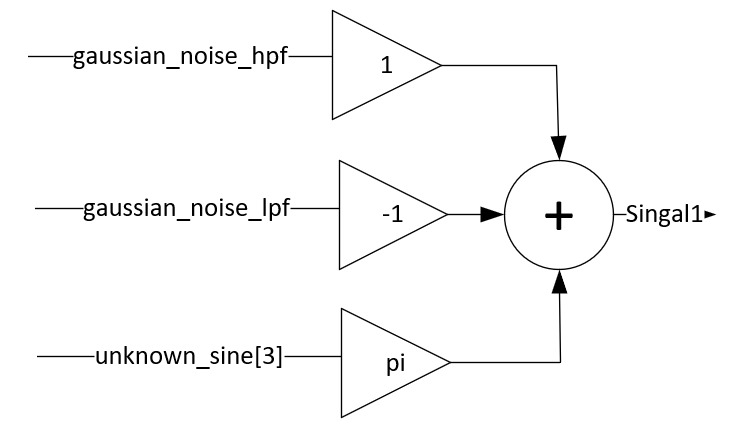

[figure not shown]

[figure not shown]

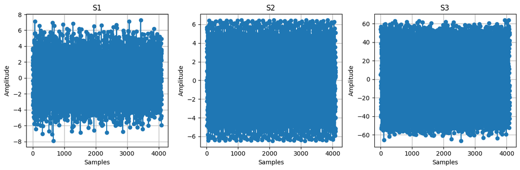

```python
index = np.arange(4096)
hw1.plot_three_side_by_side(index, signal_1, index, signal_2, index, signal_3, titles=["S1","S2","S3"])
```

#### The STFT of the Signals

We want to visualize Sine waves with the spectrogram, we know that inputting $f$ into Sine outputs `np.sin((2 * np.pi * f * n )/N + ph)`,
meaning, that $$\sin(2 \pi f \frac{n}{N}) = \sin(2 \pi f^* t) \underbrace{=}_{\text{sampled at}} x(t = \frac{n}{F_s})$$ $$ \implies f^* = \frac{f \cdot F_s}{N} [Hz]$$ We want to display the signal with normalized frequency units (for example f=1, should appear at the first frequency bin)
if we set $F_s = N$ we get that, and we inadvertently also set the spectrogram to be over 1 second of the signal (though we normalize the axis)

##### A note about displaying the STFTs

we are using `np.abs` to display the STFTs, we can create a suitable substitute by taking `Prod(signal_1, Conj(Signal_1))`.  
However we didn't do so due to numerical stability issues we encountered, and chose not to focus on since they didn't seem particularly relevant to this excersize.

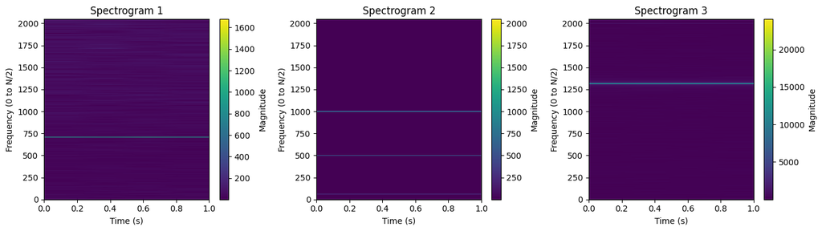

```python
def plot_three_spectrograms(signal_1,signal_2,signal_3):
    # Parameters
    N = 4096  # Total number of samples
    M = 1024   # Window size for STFT (ensures good frequency resolution)
    overlap = 0  # No overlap
    Fs = 4096  # Sampling frequency in normalized units



    matrix_1 = STFT(signal_1, M=M)
    magnitude_1 = np.abs(matrix_1)
    matrix_2 = STFT(signal_2, M=M)
    magnitude_2 = np.abs(matrix_2)
    matrix_3 = STFT(signal_3, M=M)
    magnitude_3 = np.abs(matrix_3)

    # Define frequency and time axes
    frequencies = np.linspace(0, 0.5 * N, M // 2 + 1)  # Frequency range
    time = np.linspace(0, N / Fs, (N - overlap) // (M - overlap))

    # Plot three identical spectrograms side by side
    plt.figure(figsize=(14, 4))

    # Spectrogram 1
    plt.subplot(1, 3, 1)
    plt.imshow(
        magnitude_1[:M // 2 + 1, :],  # Positive frequencies only
        extent=[time[0], time[-1], frequencies[0], frequencies[-1]],
        aspect='auto',
        origin='lower',
        cmap='viridis'
    )
    plt.colorbar(label="Magnitude")
    plt.xlabel("Time (s)")
    plt.ylabel("Frequency (0 to N/2)")
    plt.title("Spectrogram 1")

    # Spectrogram 2
    plt.subplot(1, 3, 2)
    plt.imshow(
        magnitude_2[:M // 2 + 1, :],  # Positive frequencies only
        extent=[time[0], time[-1], frequencies[0], frequencies[-1]],
        aspect='auto',
        origin='lower',
        cmap='viridis'
    )
    plt.colorbar(label="Magnitude")
    plt.xlabel("Time (s)")
    plt.ylabel("Frequency (0 to N/2)")
    plt.title("Spectrogram 2")

    # Spectrogram 3
    plt.subplot(1, 3, 3)
    plt.imshow(
        magnitude_3[:M // 2 + 1, :],  # Positive frequencies only
        extent=[time[0], time[-1], frequencies[0], frequencies[-1]],
        aspect='auto',
        origin='lower',
        cmap='viridis'
    )
    plt.colorbar(label="Magnitude")
    plt.xlabel("Time (s)")
    plt.ylabel("Frequency (0 to N/2)")
    plt.title("Spectrogram 3")

    plt.tight_layout()
    plt.show()
plot_three_spectrograms(signal_1,signal_2,signal_3)
```

### Filtering In the Frequency Domain:

We will note that in all our spectrograms the noise seems to be at a weaker amplitude with respect to our chosen signal, we can use the Thresh function to our advantage in this case.  
We will notice that our filtering is essentially done in the first spectrogram and the third - we can get rid of the unwanted lower-amplitude disturbances with the thresh function, however we can't really do the same in the second spectrogram as our signals amplitude (at $f=500$) is sandwiched inbetween the other signals, so we can remove  
one annoying sine but not the other. (at least not without making more complicated manipulations)

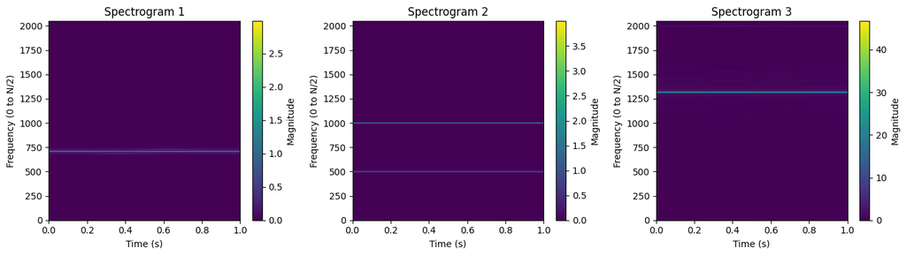

```python
signal_1_stft = STFT(signal_1, M=512)
signal_1_stft_thresh = 120
filtered_stft_1 = Threshold(signal_1_stft, signal_1_stft_thresh)
signal_1_freq_filtered = ISTFT(filtered_stft_1)

signal_2_stft = STFT(signal_2, M=512)
signal_2_stft_thresh = 320
filtered_stft_2 = Threshold(signal_2_stft, signal_2_stft_thresh)
signal_2_freq_filtered = ISTFT(filtered_stft_2)

signal_3_stft = STFT(signal_3, M=512)
signal_3_stft_thresh = 200
filtered_stft_3 = Threshold(signal_3_stft, signal_3_stft_thresh)
signal_3_freq_filtered = ISTFT(filtered_stft_3)

plot_three_spectrograms(signal_1_freq_filtered,signal_2_freq_filtered,signal_3_freq_filtered)
```

#### Filtering in the time domain:

we're having a harder time here when dealing with the noise - seeing as it encompasses all frequencies constructing a low pass filter or a high pass one does not really help us get rid of the white noise in all the spectrums. However, we can see how the usage of a low pass filter in spectrogram 2 lets us remove the high frequency sine noise that had a high intensity and was harder to remove with the thresh filtering

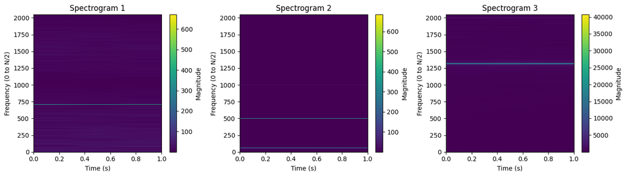

```python
signal_1_time_filtered = hw1.Filter([1], hw1.Rect(1,5,20),signal_1)
signal_2_time_filtered = hw1.Filter(an=[1],bn= hw1.Rect(1,5,10), x=signal_2)
signal_3_time_filtered = hw1.Filter([1],high_pass_filter,signal_3)
plot_three_spectrograms(signal_1_time_filtered,signal_2_time_filtered,signal_3_time_filtered)
```

### Combined Filtering

We can see how a combined filtering action lets us utilize the advantages of both methods and as such give us some really good control.

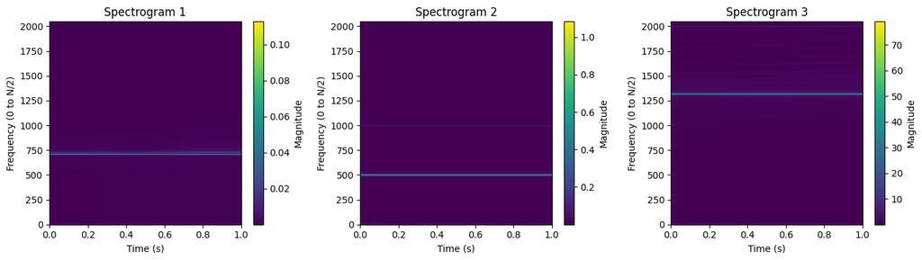

```python
signal_1_COMBIBED_filtered = hw1.Filter([1],low_pass_filter,signal_1_freq_filtered)
signal_2_COMBIBED_filtered = hw1.Filter(an=[1],bn= hw1.Rect(1,5,10), x=signal_2_freq_filtered)
signal_3_COMBIBED_filtered = hw1.Filter([1],high_pass_filter,signal_3_freq_filtered)
plot_three_spectrograms(signal_1_COMBIBED_filtered,signal_2_COMBIBED_filtered,signal_3_COMBIBED_filtered)
```